# Assessment_Zach

## Part 1

#### You have been asked to report back to managers on aspects of abandoned waste collection service in 2024. Using the Data below, your analytical and creative thinking skills and datasets provided, prepare a summary and impactful visualizations.

### 1) Please answer the following questions and provide a representative map and/or data visualization

### a. Which neighbourhood has the most abandoned waste for each category?

#### 1) Base on my findings: there are **five** categories labeled as abandoned waste

- **Abandoned Mattress Case**
- **Abandoned Non-Recyclables-Large Case**
- **Abandoned Non-Recyclables-Small Case**
- **Abandoned Recyclables Case**
- **Abandoned or Uninsured Vehicle Case**

#### Downtown has the most abandoned waste in total: **2589** Please referce this interactive dashbaord for more details: https://1zhao.github.io/Vancouver/neighbourhood.html

| Abandoned waste type | Numbers |
| --- | --- |
| Abandoned Mattress Case | **323** |
| Abandoned Non-Recyclables-Large Case | **241** |
| Abandoned Non-Recyclables-Small Case | **1321** |
| Abandoned Recyclables Case | **623** |
| Abandoned or Uninsured Vehicle Case | **81** |
| Total | **2589** |

### b. Does this change seasonally? If so, how?

#### I created a interactive dashboard: heatmap + line chart over at https://1zhao.github.io/Vancouver/seasonal.html.

#### Across Vancouver’s neighbourhoods, abandoned waste clearly peaks in the **summer months**—mattress removals jump by over 50 percent and both small and large non‐recyclable dumps climb to their highest levels, with small non‐recyclables averaging about 105 per area compared to roughly 76 in **winter**. **Spring** and **fall** sit in the middle, while winter sees the lowest numbers across every category, especially recyclables and vehicle‐related waste.

#### In short, warm weather drives more illegal dumping across all waste types, and colder seasons bring everything down.

### 2) Show us all your steps and results including data loading, cleaning, analysis in one of these formats:

- **a. Python file**; or
- i. GitHub repository (optional)
- **b. PDF**

### 3) Please include a short discussion (max 1-2 paragraphs) on any 1 of these questions:

#### a. What is interesting to you about this data?

The data intrigues me primarily due to its varying quality and diverse sources; notably, a significant portion lacks valid geometry, prompting questions about data collection methodologies and accuracy. I'm interested in how the spatial join process combines geometry-based matching with fuzzy text-based matches on neighborhood names, highlighting potential data quality issues. To enhance reliability, it would be valuable to implement consistent constraints ensuring all records have valid geometries, either through improved data collection via GPS-enabled apps or through mandatory field constraints at data entry points.

#### b. What additional information would you want to expand your analysis?

- i. How would you acquire additional data required?

To expand my analysis further, I'd incorporate hotspot analyses using pure point data rather than relying solely on neighborhood boundaries, possibly applying machine learning algorithms to identify spatial clusters. Correlation analyses with supplementary datasets, such as crime incidents, would also provide deeper insights. Investigating data quality differences between web and mobile submissions, analyzing case resolution times, and understanding root causes behind prolonged case closures could greatly enrich the analysis and demonstrate the broader value of the dataset. I'd source additional crime incident data through open city geoportals or APIs, leveraging platforms like municipal data hubs or government open-data initiatives.

#### c. Any other observations, questions to explore, comments, or recommendations you have.

One key observation is that data cleaning and ETL (Extract, Transform, Load) processes consistently consume significant amounts of project time, particularly evident in the Van311 dataset. Additionally, I encountered issues with the Parquet format provided on the open data portal, prompting me to opt for GeoJSON files instead due to their reliability and ease of handling in my workflow. I'd recommend investing effort upfront in automating data cleaning tasks—using scripts and tools like Python and FME—to streamline future analyses and ensure more time is available for deeper exploratory and predictive analytics.

### 1. Import required libraries

```python
import pandas as pd
import geopandas as gpd
from shapely.geometry import Point
import numpy as np
import re
from dash import Dash, dcc, html, Input, Output
import plotly.express as px
import json
import plotly.graph_objects as go
import plotly.io as pio
```

### 2. Data Load(GeoJson)

```python
# Load 311 service requests data
service_requests = gpd.read_file('3-1-1-service-requests_2024.geojson')
# Load boundary data
boundaries = gpd.read_file('local-area-boundary.geojson')
```

### 3.Data Schema and quality Overview

```python
service_requests.head(3)
```

|  | department | service_request_type | status | closure_reason | service_request_open_timestamp | service_request_close_date | last_modified_timestamp | address | local_area | channel | latitude | longitude | geom | geometry |
| --- | --- | --- | --- | --- | --- | --- | --- | --- | --- | --- | --- | --- | --- | --- |
| 0 | DBL - Services Centre | Building and Development Inquiry Case | Close | Service provided | 2024-11-28 08:50:00+05:30 | 2024-12-02 | 2024-12-02 22:42:48+05:30 | None | Kensington-Cedar Cottage | WEB | NaN | NaN | None | None |
| 1 | 311 Contact Centre | General Feedback Case | Close | Customer unreachable | 2024-11-28 08:56:00+05:30 | 2024-11-28 | 2024-11-29 02:54:00+05:30 | None | None | Mobile App | NaN | NaN | None | None |
| 2 | ENG - Streets Operations | Sidewalk Repair Case | Close | Further action has been planned | 2024-11-28 09:19:00+05:30 | 2024-12-05 | 2024-12-06 00:29:55+05:30 | 417 E 16TH AV | Mount Pleasant | Phone | 49.256791 | -123.095834 | None | POINT (-123.09583 49.25679) |

```python
# 311 Service Requests Data Structure
print(service_requests.columns.tolist())
print('\n')
print(service_requests.dtypes)
print('\n')
print(service_requests.crs)
print('\n')

# service_requests
print(len(service_requests))
print('\n')
print(service_requests.isnull().sum())
print('\n')
#service_requests
print(service_requests.geometry.type.value_counts())
```

```
['department', 'service_request_type', 'status', 'closure_reason', 'service_request_open_timestamp', 'service_request_close_date', 'last_modified_timestamp', 'address', 'local_area', 'channel', 'latitude', 'longitude', 'geom', 'geometry']


department                                           object
service_request_type                                 object
status                                               object
closure_reason                                       object
service_request_open_timestamp    datetime64[ms, UTC+05:30]
service_request_close_date                   datetime64[ms]
last_modified_timestamp           datetime64[ms, UTC+05:30]
address                                              object
local_area                                           object
channel                                              object
latitude                                            float64
longitude                                           float64
geom                                                 object
geometry                                           geometry
dtype: object


EPSG:4326


268066


department                             0
service_request_type                   0
status                                 0
closure_reason                         0
service_request_open_timestamp         0
service_request_close_date          3903
last_modified_timestamp                0
address                           178655
local_area                         57751
channel                                0
latitude                          178386
longitude                         178386
geom                              268066
geometry                          178386
dtype: int64


Point    89680
Name: count, dtype: int64
```

```python
boundaries.head(3)
```

|  | name | geo_point_2d | geometry |
| --- | --- | --- | --- |
| 0 | Dunbar-Southlands | { "lon": -123.18954680338996, "lat": 49.237961... | POLYGON ((-123.17017 49.24789, -123.17025 49.2... |
| 1 | Fairview | { "lon": -123.1310488653851, "lat": 49.2645404... | POLYGON ((-123.14599 49.25712, -123.1454 49.27... |
| 2 | Mount Pleasant | { "lon": -123.09851312036905, "lat": 49.263065... | POLYGON ((-123.10067 49.26913, -123.09692 49.2... |

```python
#Boundaries
print(len(boundaries))
print('\n')
print(boundaries.isnull().sum())
print('\n')
#Boundaries
print(boundaries.columns.tolist())
print('\n')
print(boundaries.dtypes)
print('\n')
print(boundaries.crs)
#Boundaries
print(boundaries.geometry.type.value_counts())
```

```
22


name            0
geo_point_2d    0
geometry        0
dtype: int64


['name', 'geo_point_2d', 'geometry']


name              object
geo_point_2d      object
geometry        geometry
dtype: object


EPSG:4326
Polygon    22
Name: count, dtype: int64
```

### 4.Analyze and handle missing geometries(service_requests)

```python
print(f"Total: {len(service_requests)}")
print(f"Valid geometry: {len(service_requests[service_requests.geometry.notna()])}")
print(f"Missing geometry: {len(service_requests[service_requests.geometry.isna()])}")
```

```
Total: 268066
Valid geometry: 89680
Missing geometry: 178386
```

```python
service_requests[service_requests.geometry.isna()].head()
```

|  | department | service_request_type | status | closure_reason | service_request_open_timestamp | service_request_close_date | last_modified_timestamp | address | local_area | channel | latitude | longitude | geom | geometry |
| --- | --- | --- | --- | --- | --- | --- | --- | --- | --- | --- | --- | --- | --- | --- |
| 0 | DBL - Services Centre | Building and Development Inquiry Case | Close | Service provided | 2024-11-28 08:50:00+05:30 | 2024-12-02 | 2024-12-02 22:42:48+05:30 | None | Kensington-Cedar Cottage | WEB | NaN | NaN | None | None |
| 1 | 311 Contact Centre | General Feedback Case | Close | Customer unreachable | 2024-11-28 08:56:00+05:30 | 2024-11-28 | 2024-11-29 02:54:00+05:30 | None | None | Mobile App | NaN | NaN | None | None |
| 3 | ENG - Sanitation Services | Missed Garbage Bin Pickup Case | Close | Reviewed and no action planned | 2024-11-28 09:20:00+05:30 | 2024-12-01 | 2024-12-02 09:04:20+05:30 | None | Renfrew-Collingwood | Phone | NaN | NaN | None | None |
| 4 | ENG - Sanitation Services | Missed Green Bin Pickup Case | Close | Service provided | 2024-11-28 09:20:00+05:30 | 2024-12-04 | 2024-12-05 10:09:00+05:30 | None | Renfrew-Collingwood | Phone | NaN | NaN | None | None |
| 5 | ENG - Sanitation Services | Missed Green Bin Pickup Case | Close | Service provided | 2024-11-28 09:24:00+05:30 | 2024-12-04 | 2024-12-05 10:09:00+05:30 | None | Renfrew-Collingwood | WEB | NaN | NaN | None | None |

```python
def clean_and_repair_geometries(gdf):
    original_count = len(gdf)
    cleaned_gdf = gdf.copy()

    invalid_geom_count = cleaned_gdf.geometry.isna().sum()
    if invalid_geom_count > 0:
        print(f"\nRemoving {invalid_geom_count} records with invalid geometries...")
        cleaned_gdf = cleaned_gdf[cleaned_gdf.geometry.notna()]

    invalid_shapes = ~cleaned_gdf.geometry.is_valid
    if invalid_shapes.any():
        print(f"\nRepairing {invalid_shapes.sum()} invalid geometries...")
        cleaned_gdf.geometry = cleaned_gdf.geometry.buffer(0)

    final_count = len(cleaned_gdf)
    print(f"\nCleaning complete:")
    print(f"Original records: {original_count}")
    print(f"Cleaned records: {final_count}")
    print(f"Removed records: {original_count - final_count}")

    return cleaned_gdf

cleaned_service_requests = clean_and_repair_geometries(service_requests)

print("\n=== Verification of Cleaned Data ===")
print(f"Total records: {len(cleaned_service_requests)}")
print(f"Records with valid geometry: {len(cleaned_service_requests[cleaned_service_requests.geometry.notna()])}")
print("\nGeometry types:")
print(cleaned_service_requests.geometry.type.value_counts())
```

```
Removing 178386 records with invalid geometries...

Cleaning complete:
Original records: 268066
Cleaned records: 89680
Removed records: 178386

=== Verification of Cleaned Data ===
Total records: 89680
Records with valid geometry: 89680

Geometry types:
Point    89680
Name: count, dtype: int64
```

### 5.Quality Check before the formal spatial join

```python
joined_data = gpd.sjoin(cleaned_service_requests, boundaries, how='left', predicate='within')
print(f"Original: {len(cleaned_service_requests)}")
print(f"Joined: {len(joined_data)}")
print(f"Matched: {len(joined_data.dropna(subset=['index_right']))}")
print(f"Not Matched: {len(joined_data[joined_data['index_right'].isna()])}")
print("\nSample of joined data:")
joined_data.head()
```

```
Original: 89680
Joined: 89702
Matched: 88743
Not Matched: 959

Sample of joined data:
```

|  | department | service_request_type | status | closure_reason | service_request_open_timestamp | service_request_close_date | last_modified_timestamp | address | local_area | channel | latitude | longitude | geom | geometry | index_right | name | geo_point_2d |
| --- | --- | --- | --- | --- | --- | --- | --- | --- | --- | --- | --- | --- | --- | --- | --- | --- | --- |
| 2 | ENG - Streets Operations | Sidewalk Repair Case | Close | Further action has been planned | 2024-11-28 09:19:00+05:30 | 2024-12-05 | 2024-12-06 00:29:55+05:30 | 417 E 16TH AV | Mount Pleasant | Phone | 49.256791 | -123.095834 | None | POINT (-123.09583 49.25679) | 2.0 | Mount Pleasant | { "lon": -123.09851312036905, "lat": 49.263065... |
| 12 | ENG - Sanitation Services | Dead Animal Pick Up Case | Close | Issue not found or inaccessible | 2024-11-28 10:43:00+05:30 | 2024-11-29 | 2024-11-30 00:00:29+05:30 | 2926 FRASER ST | Mount Pleasant | Phone | 49.258431 | -123.088820 | None | POINT (-123.08882 49.25843) | 2.0 | Mount Pleasant | { "lon": -123.09851312036905, "lat": 49.263065... |
| 13 | ENG - Sanitation Services | Abandoned Mattress Case | Close | Service provided | 2024-11-28 10:47:33+05:30 | 2024-12-02 | 2024-12-02 21:55:10+05:30 | 2158 KINGSWAY | Kensington-Cedar Cottage | Mobile App | 49.243598 | -123.062947 | None | POINT (-123.06295 49.2436) | 7.0 | Kensington-Cedar Cottage | { "lon": -123.07288459215947, "lat": 49.246686... |
| 14 | ENG - Sanitation Services | Abandoned Non-Recyclables-Large Case | Close | Service provided | 2024-11-28 10:47:00+05:30 | 2024-12-02 | 2024-12-02 22:15:11+05:30 | 2158 KINGSWAY | Kensington-Cedar Cottage | Mobile App | 49.243634 | -123.062703 | None | POINT (-123.0627 49.24363) | 7.0 | Kensington-Cedar Cottage | { "lon": -123.07288459215947, "lat": 49.246686... |
| 17 | ENG - Streets Operations | Sidewalk Repair Case | Close | Referred to another service group | 2024-11-28 11:29:04+05:30 | 2024-11-28 | 2024-11-29 04:44:08+05:30 | 1915 HARO ST | West End | WEB | 49.292164 | -123.138075 | None | POINT (-123.13808 49.29216) | 4.0 | West End | { "lon": -123.13543765302629, "lat": 49.285011... |

### 6.Using regex to match

```python
def clean_string(s):
    """Clean a string for fuzzy matching."""
    return '' if pd.isna(s) else re.sub(r'[^a-zA-Z0-9]', '', str(s).lower())

def find_best_match(source, targets):
    """Find best fuzzy match from a list of targets."""
    source_clean = clean_string(source)
    cleaned_targets = {clean_string(t): t for t in targets}
    if source_clean in cleaned_targets:
        return cleaned_targets[source_clean]
    for cleaned, original in cleaned_targets.items():
        if source_clean in cleaned or cleaned in source_clean:
            return original
    return None

def _apply_spatial_join(df, boundaries):
    """Perform spatial join for records with geometry."""
    subset = df[df.geometry.notna()].copy()
    joined = gpd.sjoin(subset, boundaries[['name', 'geometry']], how='left', predicate='within')
    df.loc[joined.index, 'matched_area_name'] = joined['name']
    matched = joined['name'].notna()
    df.loc[joined[matched].index, ['spatial_join_status', 'join_source']] = ['Y', 'geometry']
    return df

def _apply_regex_match(df, boundaries):
    """Fallback match using regex on 'local_area'."""
    names = boundaries['name'].unique().tolist()
    fallback = df.geometry.isna() & df['local_area'].notna()
    for i in df[fallback].index:
        match = find_best_match(df.at[i, 'local_area'], names)
        if match:
            df.loc[i, ['matched_area_name', 'spatial_join_status', 'join_source']] = [match, 'Y', 'Regex_name']
    return df

def process_spatial_join(points, boundaries):
    """Main function: spatial join with regex fallback."""
    df = points.copy()
    df[['spatial_join_status', 'join_source', 'matched_area_name']] = ['N', 'N/A', None]

    if df.geometry.notna().any():
        print(f"Processing {df.geometry.notna().sum()} records with valid geometry...")
        df = _apply_spatial_join(df, boundaries)

    if (df.geometry.isna() & df['local_area'].notna()).any():
        print(f"Processing {(df.geometry.isna() & df['local_area'].notna()).sum()} records using regex matching...")
        df = _apply_regex_match(df, boundaries)

    return df
```

```python
processed_data_test = process_spatial_join(service_requests,boundaries)
```

```
Processing 89680 records with valid geometry...
Processing 121593 records using regex matching...
```

### 6.Analyze the final match results

```python
def analyze_matching_results(processed_gdf, boundaries_gdf):
    # Overall statistics
    total_records = len(processed_gdf)
    successful_matches = (processed_gdf['spatial_join_status'] == 'Y').sum()
    failed_matches = (processed_gdf['spatial_join_status'] == 'N').sum()

    print(f"\nOverall Statistics:")
    print(f"Total records: {total_records}")
    print(f"Successful matches: {successful_matches} ({successful_matches/total_records*100:.2f}%)")
    print(f"Failed matches: {failed_matches} ({failed_matches/total_records*100:.2f}%)")

    # Join source breakdown
    print("\nJoin Source Breakdown:")
    source_counts = processed_gdf['join_source'].value_counts()
    for source, count in source_counts.items():
        print(f"{source}: {count} ({count/total_records*100:.2f}%)")

    # Analyze unmatched records
    unmatched = processed_gdf[processed_gdf['spatial_join_status'] == 'N']
    print("\nUnmatched Records Analysis:")
    print(f"Records without geometry: {unmatched.geometry.isna().sum()}")
    print(f"Records without local_area: {unmatched.local_area.isna().sum()}")
analyze_matching_results(processed_data_test, boundaries)
```

```
Overall Statistics:
Total records: 268066
Successful matches: 210314 (78.46%)
Failed matches: 57752 (21.54%)

Join Source Breakdown:
Regex_name: 121593 (45.36%)
geometry: 88721 (33.10%)
N/A: 57752 (21.54%)

Unmatched Records Analysis:
Records without geometry: 56793
Records without local_area: 57751
```

### 7.Prepare dataframe for analysis/visualization(tag abandoned waste using regex)

```python
def tag_abandoned_waste(processed_data):
    # Filter only spatially joined records
    df = processed_data[processed_data['spatial_join_status'] == 'Y'].copy()

    # Define regex pattern to match 'abandoned' (case-insensitive)
    pattern = re.compile(r'abandoned', re.IGNORECASE)

    # Apply regex to create the 'abandoned_waste' flag
    df['abandoned_waste'] = df['service_request_type'].apply(
        lambda x: 'Y' if pattern.search(str(x)) else 'N'
    )

    return df
```

```python
abandoned_waste_tag_gdf = tag_abandoned_waste(processed_data_test)
```

```python
abandoned_waste_tag_gdf.head(3)
```

|  | department | service_request_type | status | closure_reason | service_request_open_timestamp | service_request_close_date | last_modified_timestamp | address | local_area | channel | latitude | longitude | geom | geometry | spatial_join_status | join_source | matched_area_name | abandoned_waste |
| --- | --- | --- | --- | --- | --- | --- | --- | --- | --- | --- | --- | --- | --- | --- | --- | --- | --- | --- |
| 0 | DBL - Services Centre | Building and Development Inquiry Case | Close | Service provided | 2024-11-28 08:50:00+05:30 | 2024-12-02 | 2024-12-02 22:42:48+05:30 | None | Kensington-Cedar Cottage | WEB | NaN | NaN | None | None | Y | Regex_name | Kensington-Cedar Cottage | N |
| 2 | ENG - Streets Operations | Sidewalk Repair Case | Close | Further action has been planned | 2024-11-28 09:19:00+05:30 | 2024-12-05 | 2024-12-06 00:29:55+05:30 | 417 E 16TH AV | Mount Pleasant | Phone | 49.256791 | -123.095834 | None | POINT (-123.09583 49.25679) | Y | geometry | Mount Pleasant | N |
| 3 | ENG - Sanitation Services | Missed Garbage Bin Pickup Case | Close | Reviewed and no action planned | 2024-11-28 09:20:00+05:30 | 2024-12-01 | 2024-12-02 09:04:20+05:30 | None | Renfrew-Collingwood | Phone | NaN | NaN | None | None | Y | Regex_name | Renfrew-Collingwood | N |

### 8.Prepare dataframe for analysis/visualization(flatten abandoned waste to new columns)

```python
def flatten_abandoned_waste(boundaries, gdf):
    df = gdf[gdf["abandoned_waste"] == "Y"]
    counts = df.groupby(["matched_area_name", "service_request_type"]).size().reset_index(name="count")
    merged = boundaries.merge(counts, left_on="name", right_on="matched_area_name", how="left")
    wide = merged.pivot_table(index="name", columns="service_request_type", values="count", fill_value=0).reset_index()
    wide["total"] = wide.drop(columns="name").sum(axis=1)
    return boundaries.drop_duplicates("name")[["name", "geometry"]].merge(wide, on="name")
```

```python
categoried_abandoned_waste_neighbourhood = flatten_abandoned_waste(boundaries,abandoned_waste_tag_gdf).sort_values("total")
```

```python
categoried_abandoned_waste_neighbourhood.dtypes
```

```
name                                      object
geometry                                geometry
Abandoned Mattress Case                  float64
Abandoned Non-Recyclables-Large Case     float64
Abandoned Non-Recyclables-Small Case     float64
Abandoned Recyclables Case               float64
Abandoned or Uninsured Vehicle Case      float64
total                                    float64
dtype: object
```

### 9.Dashboard(Abandoned Waste By Neighbourhood)

```python
gdf = categoried_abandoned_waste_neighbourhood.copy().to_crs(epsg=4326)
gdf = gdf.fillna(0)

categories = [
    "Abandoned Mattress Case",
    "Abandoned Non-Recyclables-Large Case",
    "Abandoned Non-Recyclables-Small Case",
    "Abandoned Recyclables Case",
    "Abandoned or Uninsured Vehicle Case",
    "total"
]

app = Dash(__name__)
app.layout = html.Div([
    html.H2("Abandoned Waste By Neighbourhood"),
    html.Label("Select Waste Category:"),
    dcc.Dropdown(
        id="waste_type",
        options=[{"label": c, "value": c} for c in categories],
        value=categories[0]
    ),
    dcc.Graph(id="map"),
    dcc.Graph(id="bar")
])

@app.callback(
    Output("map", "figure"),
    Output("bar", "figure"),
    Input("waste_type", "value")
)
def update_charts(category):
    gdf["id"] = gdf.index.astype(str)
    geojson = json.loads(gdf.to_json())

    gdf["hover"] = gdf.apply(lambda row: (
        f"<b>{row['name']}</b><br>" +
        "".join([f"{cat}: {int(row[cat])}<br>" for cat in categories[:-1]]) +
        f"<b>Total:</b> {int(row['total'])}"
    ), axis=1)

    fig_map = go.Figure(go.Choroplethmapbox(
        geojson=geojson,
        locations=gdf["id"],
        z=gdf[category],
        colorscale="YlOrRd",
        marker_opacity=0.75,
        marker_line_width=0.5,
        featureidkey="properties.id",
        hovertext=gdf["hover"],
        hoverinfo="text"
    ))


    fig_map.update_layout(
        mapbox_style="open-street-map",  # OSM base tiles
        mapbox_zoom=10.5,
        mapbox_center={"lat": 49.25, "lon": -123.1},
        margin={"r": 0, "t": 30, "l": 0, "b": 0},
        title=f"{category} by Neighbourhood"
    )

    # Bar chart
    fig_bar = px.bar(
        gdf.sort_values(by=category, ascending=False),
        x="name",
        y=category,
        labels={"name": "Neighbourhood", category: "Reports"},
        title="Neighbourhood Breakdown"
    )
    return fig_map, fig_bar

app.run(debug=False, use_reloader=False, port=8051)
```

[interactive chart not shown]

### 10.Extract the seasn by service_request_close_date

```python
def abandoned_waste_season(boundaries, gdf):
    def season(d):
        m, d = d.month, d.day
        return ("Winter" if (m == 12 and d >= 21) or m in [1, 2] or (m == 3 and d < 21)
                else "Spring" if m < 6 or (m == 6 and d <= 21)
                else "Summer" if m < 9 or (m == 9 and d <= 22)
                else "Fall")

    df = gdf[gdf["abandoned_waste"] == "Y"].copy()
    df["season"] = pd.to_datetime(df["service_request_close_date"], errors="coerce").apply(season)

    agg = df.groupby(["matched_area_name", "service_request_type", "season"]).size().reset_index(name="count")
    merged = boundaries.merge(agg, left_on="name", right_on="matched_area_name", how="left")

    pivot = merged.pivot_table(index=["name", "season"], columns="service_request_type", values="count", fill_value=0).reset_index()
    value_cols = [col for col in pivot.columns if col not in ["name", "season"]]
    pivot["total"] = pivot[value_cols].sum(axis=1)

    return boundaries.drop_duplicates("name")[["name", "geometry"]].merge(pivot, on="name")
```

```python
categoried_abandoned_waste_season = abandoned_waste_season(boundaries, abandoned_waste_tag_gdf)
```

### 11.Dashboard(Seasonal Abandoned Waste Heatmap)

```python
from dash import Dash, dcc, html, Input, Output
import pandas as pd
import plotly.graph_objects as go
import plotly.express as px

subcategories = [
    "Abandoned Mattress Case",
    "Abandoned Non-Recyclables-Large Case",
    "Abandoned Non-Recyclables-Small Case",
    "Abandoned Recyclables Case",
    "Abandoned or Uninsured Vehicle Case",
    "total"
]


app = Dash(__name__)
app.title = "Seasonal Abandoned Waste Heatmap"

app.layout = html.Div([
    html.H2("Seasonal Abandoned Waste Heatmap"),
    html.Label("Select Waste Subcategory:"),
    dcc.Dropdown(
        id="category",
        options=[{"label": cat, "value": cat} for cat in subcategories],
        value=subcategories[0],
        style={"width": "60%"}
    ),
    dcc.Graph(id="heatmap"),
    dcc.Graph(id="linechart")
])


@app.callback(
    Output("heatmap", "figure"),
    Output("linechart", "figure"),
    Input("category", "value")
)
def update_visuals(category):
    pivot = categoried_abandoned_waste_season.pivot(index="season", columns="name", values=category).fillna(0)

    # Heatmap hover and emoji axis
    season_emoji = {"Winter": "❄️ Winter", "Spring": "🌸 Spring", "Summer": "☀️ Summer", "Fall": "🍂 Fall"}
    y_labels = [season_emoji.get(s, s) for s in pivot.index]

    hover_data = [[f"{category}<br>Season: {pivot.index[i]}<br>Neighbourhood: {col}<br>Count: {int(pivot.iloc[i,j])}"
                   for j, col in enumerate(pivot.columns)]
                  for i in range(len(pivot))]

    fig_heat = go.Figure(go.Heatmap(
        z=pivot.values,
        x=pivot.columns,
        y=y_labels,
        text=hover_data,
        hoverinfo="text",
        colorscale="YlOrRd"
    ))
    fig_heat.update_layout(
        title=f"{category} by Season and Neighbourhood",
        xaxis_title="Neighbourhood",
        yaxis_title="Season",
        xaxis_tickangle=-45
    )

    # Line chart (total reports per season)
    line_data = categoried_abandoned_waste_season.groupby("season")[category].sum().reset_index()
    line_data["season_emoji"] = line_data["season"].map(season_emoji)

    fig_line = px.line(
        line_data,
        x="season_emoji",
        y=category,
        markers=True,
        title=f"Total {category} Reports by Season",
        labels={category: "Report Count", "season_emoji": "Season"}
    )

    return fig_heat, fig_line



# Run the app
if __name__ == "__main__":
    app.run(debug=True, port=8052)
```

[interactive chart not shown]

## Part 2 “Quick Report”

### You have been asked to write a “quick report” on active park litter container collection routes. The requester asked to view the containers that are part of the street litter (SL) collection routes and what days they are serviced. However, the data resides in different tables in the database.

### Diagram 1 shows a relational data model with a small subset of records that are combined to create the output view in Table 1. Please write the SQL Query (select statement) required to join and filter the tables and get the output in Table 1.

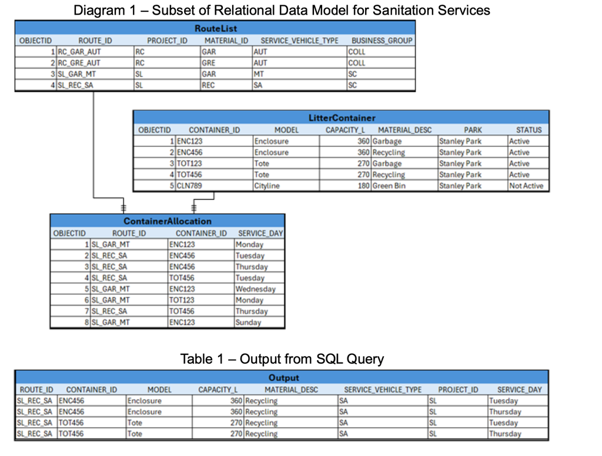

### SQL Query:

```
SELECT ca.ROUTE_ID,
    ca.CONTAINER_ID,
    lc.MODEL,
    lc.CAPACITY_L,
    lc.MATERIAL_DESC,
    rl.SERVICE_VEHICLE_TYPE,
    rl.PROJECT_ID,ca.SERVICE_DAY
FROM ContainerAllocation ca
JOIN LitterContainer lc ON ca.CONTAINER_ID = lc.CONTAINER_ID
JOIN RouteList rl ON ca.ROUTE_ID = rl.OBJECTID
WHERE ca.ROUTE_ID = 'SL_REC_SA'
    AND lc.STATUS = 'Active'
    AND lc.MATERIAL_DESC = 'Recycling' -- can be removed if uncessary
    AND rl.PROJECT_ID = 'SL' -- -- can be removed if uncessary
    AND rl.SERVICE_VEHICLE_TYPE = 'SA' -- -- can be removed if uncessary
ORDER BY ca.ROUTE_ID,
    ca.CONTAINER_ID,
    ca.SERVICE_DAY;
```